# Exploratory Data Analysis. Lab 4

- Что такое **разведочный анализ данных** (Exploratory Data Analysis)? Как вы думаете?

### Чеклист разведочного анализа данных

1. Сформулируйте вопрос
2. Загрузите / подготовьте данные
3. Проверьте, все ли в порядке с данными
   4. Выполните `str()`
   5. Посмотрите на первые и последние строки датасета
   6. Проверьте числа (“n”s)
   7. Сопоставьте как минимум с еще одним источником данных
4. Сначала проверьте простое решение
5. Усовершенствуйте свое решение
6. Сделайте выводы

#### 1. Формулировка вопроса

- Есть ли какие-то правила и требования к вопросу?
- Является ли хорошим вопрос “Какая модель автомобиля лучше”? Что нужно, чтобы на него ответить?

#### 2. Загрузка данных

Именно к этому пункту относится загрузка данных (в зависимости от формата файла), чистка данных: различные действия с преобразованиями классов, форматирование, исправление ошибок и опечаток и т.д.

Мы же сегодня продолжаем работать с данными о характеристиках 38 популярных моделей автомобилей с 1999 по 2008 г.

```r
library(ggplot2)
```

Загружаем данные. О чем они?

```r
data(mpg)

?ggplot2::mpg
```

#### 3-7. Проверка данных

Посмотрим на данные. Сколько переменных и наблюдений мы имеем? Совпадают ли данные с описанием?

```r
dim(mpg)
```

```
## [1] 234  11
```

```r
head(mpg, n = 3)
```

```
##   manufacturer model displ year cyl      trans drv cty hwy fl   class
## 1         audi    a4   1.8 1999   4   auto(l5)   f  18  29  p compact
## 2         audi    a4   1.8 1999   4 manual(m5)   f  21  29  p compact
## 3         audi    a4   2.0 2008   4 manual(m6)   f  20  31  p compact
```

```r
str(mpg)
```

```
## Classes 'tbl_df', 'tbl' and 'data.frame':    234 obs. of  11 variables:
##  $ manufacturer: chr  "audi" "audi" "audi" "audi" ...
##  $ model       : chr  "a4" "a4" "a4" "a4" ...
##  $ displ       : num  1.8 1.8 2 2 2.8 2.8 3.1 1.8 1.8 2 ...
##  $ year        : int  1999 1999 2008 2008 1999 1999 2008 1999 1999 2008 ...
##  $ cyl         : int  4 4 4 4 6 6 6 4 4 4 ...
##  $ trans       : chr  "auto(l5)" "manual(m5)" "manual(m6)" "auto(av)" ...
##  $ drv         : chr  "f" "f" "f" "f" ...
##  $ cty         : int  18 21 20 21 16 18 18 18 16 20 ...
##  $ hwy         : int  29 29 31 30 26 26 27 26 25 28 ...
##  $ fl          : chr  "p" "p" "p" "p" ...
##  $ class       : chr  "compact" "compact" "compact" "compact" ...
```

Проверим, данные о машинах какого класса у нас есть. Сколько таких классов?

```r
table(mpg$class)
```

```
##
##    2seater    compact    midsize    minivan     pickup subcompact
##          5         47         41         11         33         35
##        suv
##         62
```

```r
table(mpg$year)
```

```
##
## 1999 2008
##  117  117
```

Как представлены производители в датасете?

```r
table(mpg$manufacturer)
```

```
##
##       audi  chevrolet      dodge       ford      honda    hyundai
##         18         19         37         25          9         14
##       jeep land rover    lincoln    mercury     nissan    pontiac
##          8          4          3          4         13          5
##     subaru     toyota volkswagen
##         14         34         27
```

Таким образом, мы выполнили п.4-6 чеклиста.

п.7 (Сравнение с еще одним источником данных) более актуален для реальных, а не учебных датасетов - похожи ли цифры на правильные (один и тот же порядок, одни и те же единицы измерения)

#### 8. Простое решение

Не нужно сразу строить сложные модели и проводить особые тесты – начните с простого. Одним из удобных методов разведочного анализа являются графики. Они позволяют

- понять основные особенности данных
- увидеть простые закономерности
- заложить основу для построения более сложных моделей
- выполнить эту часть анализа достаточно быстро

А сейчас отвлечемся от пунктов чеклиста и перейдем к инструменту, который позволит строить графики.

## Пакет ggplot2

> “In brief, the grammar tells us that a statistical graphic is a mapping from data to aesthetic attributes (colour, shape, size) of geometric objects (points, lines, bars). The plot may also contain statistical transformations of the data and is drawn on a specific coordinate system”
- Wickham, H. (2009). *ggplot2: elegant graphics for data analysis*. Springer Science & Business Media.

Пакет `ggplot2`, написанный Hadley Wickham, является реализацией “Грамматики графики” (Leland Wilkinson)

- Сайт: ggplot2.org
- Документация: [docs.ggplot2.org](http://docs.ggplot2.org/)
- [Шпаргалка](https://www.rstudio.com/wp-content/uploads/2015/03/ggplot2-cheatsheet.pdf)

Многое в функциях задано по умолчанию, но есть возможность изменения, так что можно сделать любые персональные модификации

**Загрузка пакета** (повторение)

```r
library(ggplot2)
```

**Основные компоненты**:

- **data frame** = источник данных
- **aesthetic mappings** = как данным сопоставляется цвет / размер / положение (x vs y) и т.д.
- **geoms** = геометрические объекты (точки, линии, формы)
- **facets** = графики с условиями (разделениями по классам, например)
- **stats** = статистические преобразования (сглаживание, разделение на промежутки и т.д.)
- **scales** = описание шкал (например, male = red, female = blue)
- **coordinate system** = система координат, в которой строится график

Любой график строится слоями:

- `g <- ggplot(data, aes(variable1, variable2))` = создание объекта, соответствующего графику, и указание используемого датасета
  - `aes(x = variable1, y = variable2)` = описание эстетик (в данном случае – какую переменную мы берем за x, а какую – за y)
  - `geom_point()` = построение точечного графика на основе указанной ранее информации

**Эстетики**

- `+ geom_point(color, size, alpha)` = определение стиля, согласно которому будет нарисованы точки
  - *Внимание*: текущее описание справедливо и для других типов графиков (geom_…)
  - `color = "blue"` = задание цвета точек
  - `aes(color = var1)` = задание цвета через категориальную (factor) переменную – каждой категории будет соответствовать свой цвет, отличающийся от остальных
  - `size = 4` = задание размера точек
  - `alpha = 0.5` = задание прозрачности точек
- [Пример](http://docs.ggplot2.org/current/aes_colour_fill_alpha.html)
- Что вообще можно менять на графиках?
  - Цвет/заливку (color, fill)
  - Размер (size)
  - Прозрачность (alpha)
  - Форму (shape)
  - P.S.: На самом деле менять можно почти все, но об этом чуть позднее.

## Разведочные графики

#### Simple Summaries: одна переменная

- Сводная информация (Summary)
- Столбчатая диаграмма (Barplot)
- Гистограмма (Histogram)
- “Ящик с усами”" (Boxplot)

```r
summary(mpg)
```

```
##  manufacturer          model               displ            year
##  Length:234         Length:234         Min.   :1.600   Min.   :1999
##  Class :character   Class :character   1st Qu.:2.400   1st Qu.:1999
##  Mode  :character   Mode  :character   Median :3.300   Median :2004
##                                        Mean   :3.472   Mean   :2004
##                                        3rd Qu.:4.600   3rd Qu.:2008
##                                        Max.   :7.000   Max.   :2008
##       cyl           trans               drv                 cty
##  Min.   :4.000   Length:234         Length:234         Min.   : 9.00
##  1st Qu.:4.000   Class :character   Class :character   1st Qu.:14.00
##  Median :6.000   Mode  :character   Mode  :character   Median :17.00
##  Mean   :5.889                                         Mean   :16.86
##  3rd Qu.:8.000                                         3rd Qu.:19.00
##  Max.   :8.000                                         Max.   :35.00
##       hwy             fl               class
##  Min.   :12.00   Length:234         Length:234
##  1st Qu.:18.00   Class :character   Class :character
##  Median :24.00   Mode  :character   Mode  :character
##  Mean   :23.44
##  3rd Qu.:27.00
##  Max.   :44.00
```

Столбчатая диаграмма:

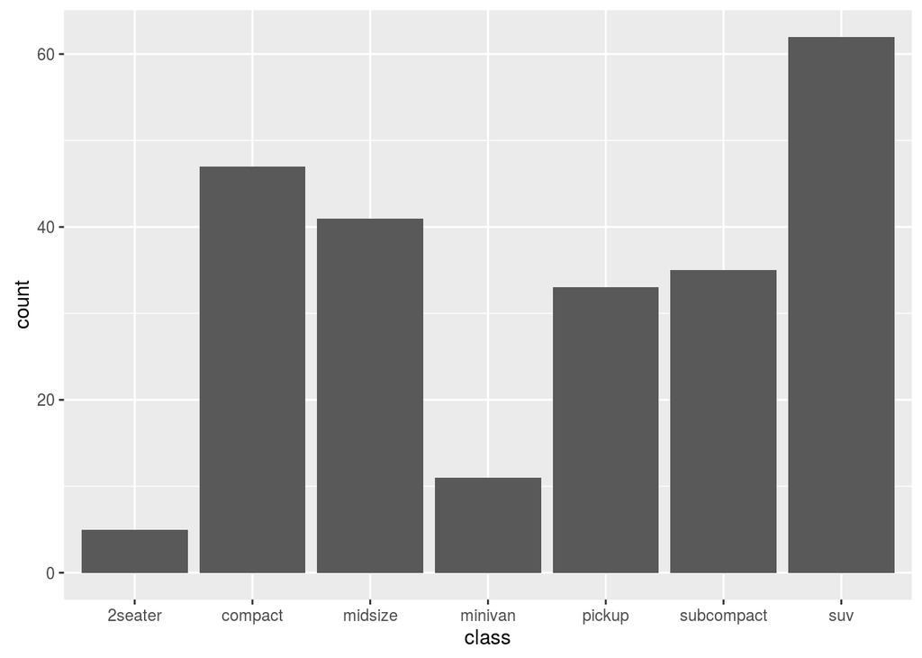

```r
ggplot() +
  geom_bar(data = mpg, aes(x = class))
```

Сколько миль (по городу) проедут автомобили на одном галлоне топлива? (Гистограмма)

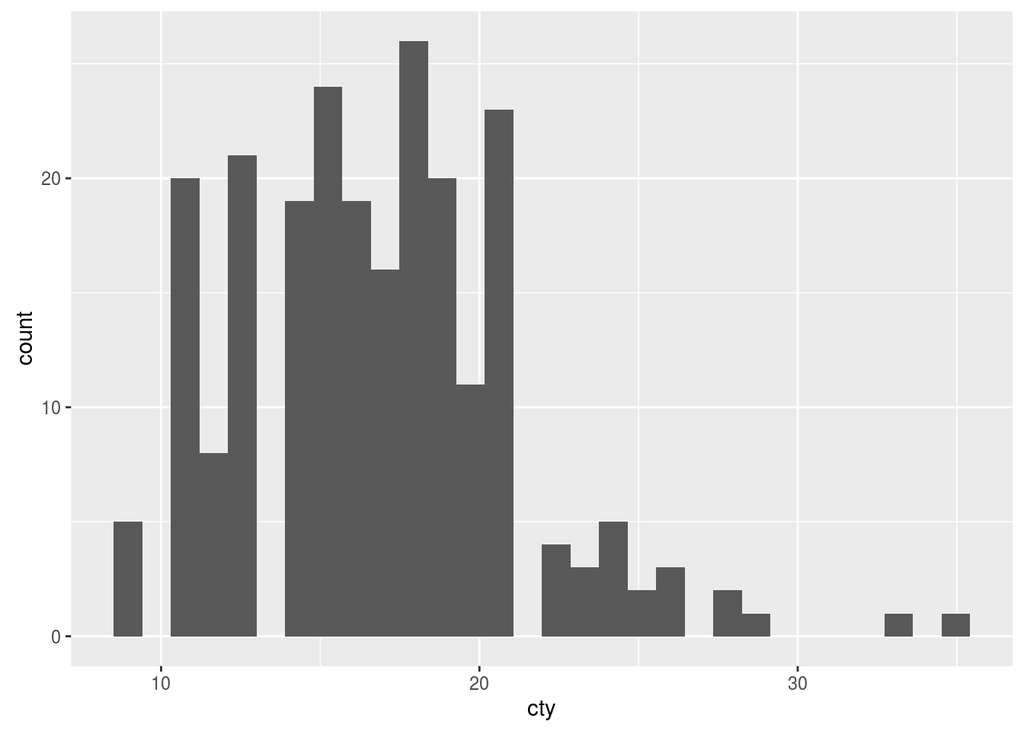

```r
ggplot() +
  geom_histogram(data = mpg, aes(x = cty))
```

А если нам нужно понять, насколько значения отклоняются от обобщенного показателя? Посчитаем среднее и медиану:

- что такое медиана
- в чем ее отличие от среднего

```r
?mean
?median

mean(mpg$cty)
```

```
## [1] 16.85897
```

```r
median(mpg$cty)
```

```
## [1] 17
```

Графики в ggplot2 строятся слоями: можно сохранить результат в переменную, а потом “дорисовывать” следующие части.

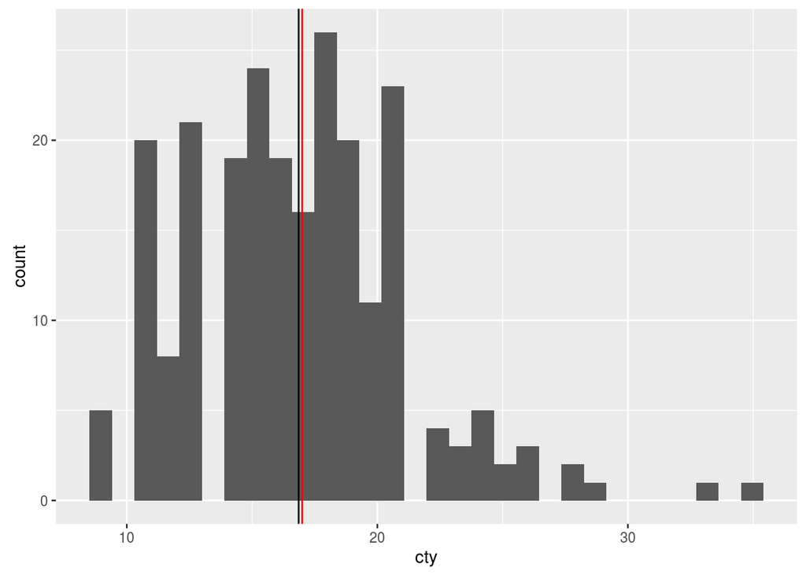

```r
g <- ggplot() +
  geom_histogram(data = mpg, aes(x = cty))

g + geom_vline(xintercept = mean(mpg$cty)) + geom_vline(xintercept = median(mpg$cty), color="red")
```

Сколько миль (по городу) проедут автомобили на одном галлоне топлива? (Боксплот)

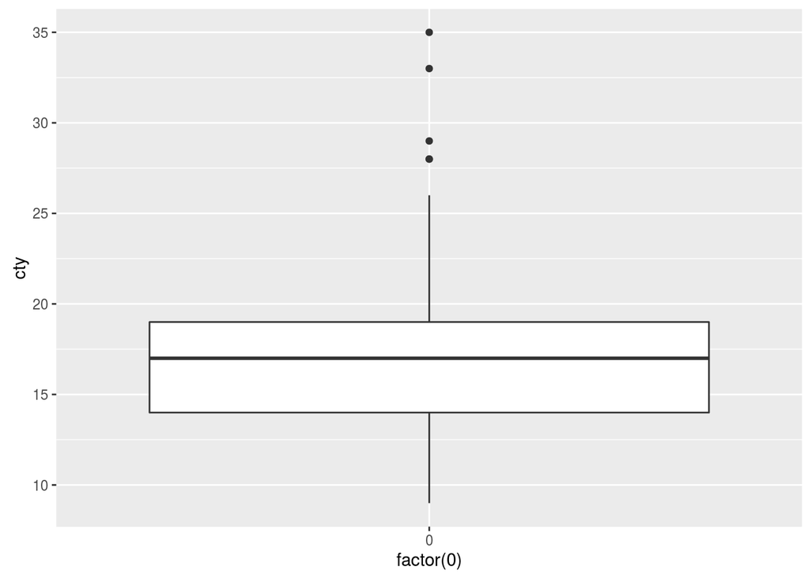

```r
ggplot() +
  geom_boxplot(data = mpg, aes(x = factor(0), y = cty))
```

- В чем отличительные черты гистограммы и боксплота, если они визуализируют одни и те же данные? В каких случаях следует использовать боксплот, а в каких гистограмму?
- Данные каких типов можно использовать для каких графиков?
  - Столбчатая диаграмма (Barplot)
  - Гистограмма (Histogram)
  - “Ящик с усами”" (Boxplot)

## Simple Summaries: две переменных

- Диаграмма рассеяния (Scatterplot)
- Комбинации графиков с одной переменной (Multiple or overlayed 1-D plot)
- Использование цвета, размера, формы для увеличения размерности

Какой класс автомобилей наиболее экономичный?

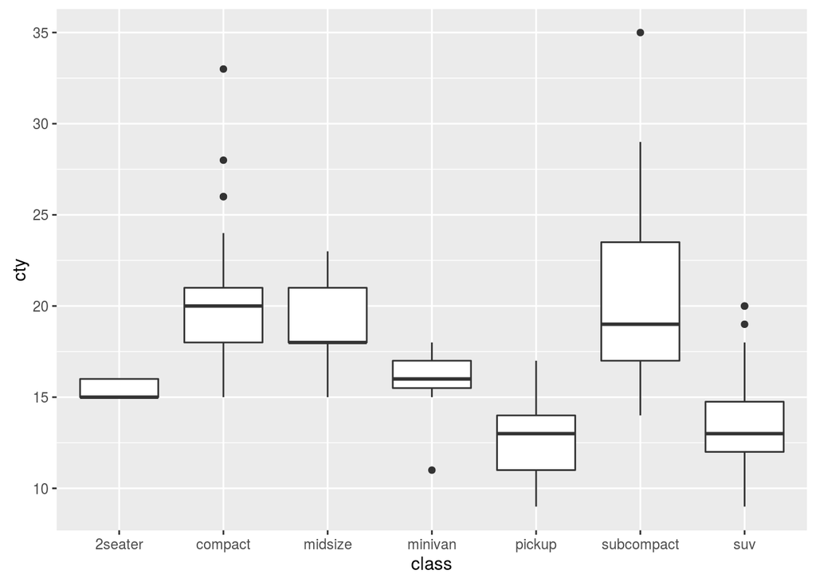

```r
ggplot() +
  geom_boxplot(data = mpg, aes(x = class, y = cty))
```

У машин с каким типом привода расход топлива больше?

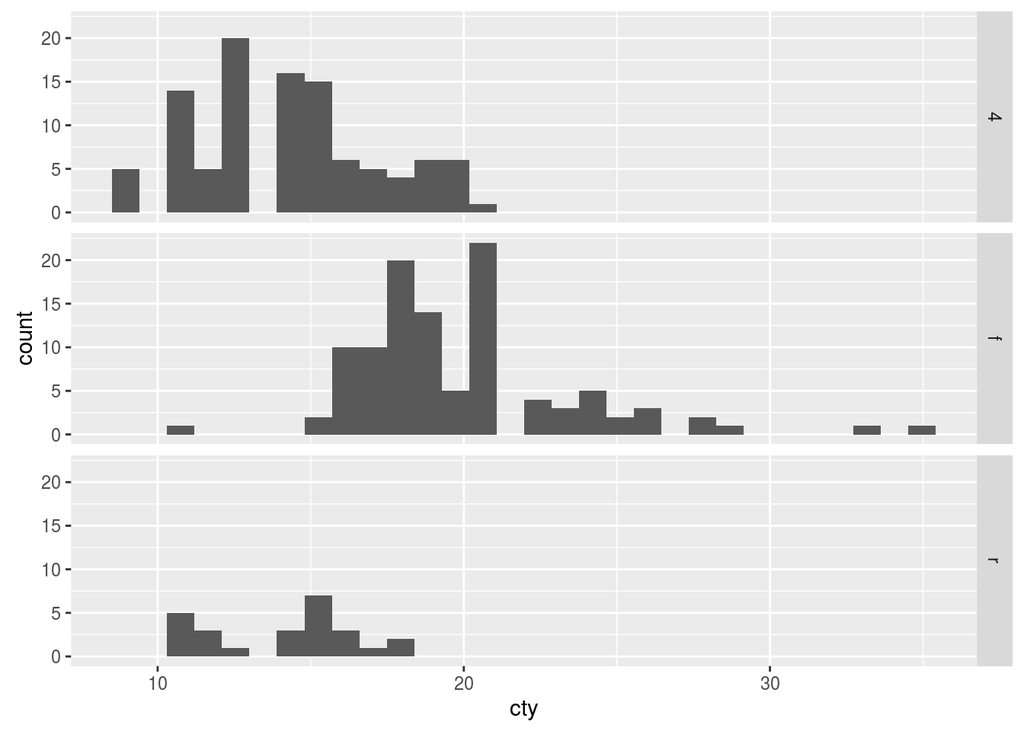

```r
ggplot() +
  geom_histogram(data = mpg, aes(x = cty)) +
  facet_grid(drv~.)
```

Как связана экономичность автомобиля и объем двигателя?

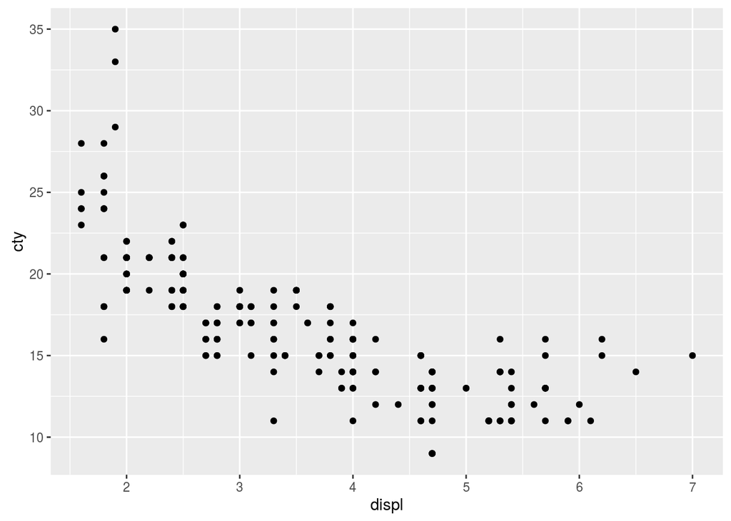

```r
ggplot() +
  geom_point(data = mpg, aes(x = displ, y = cty))
```

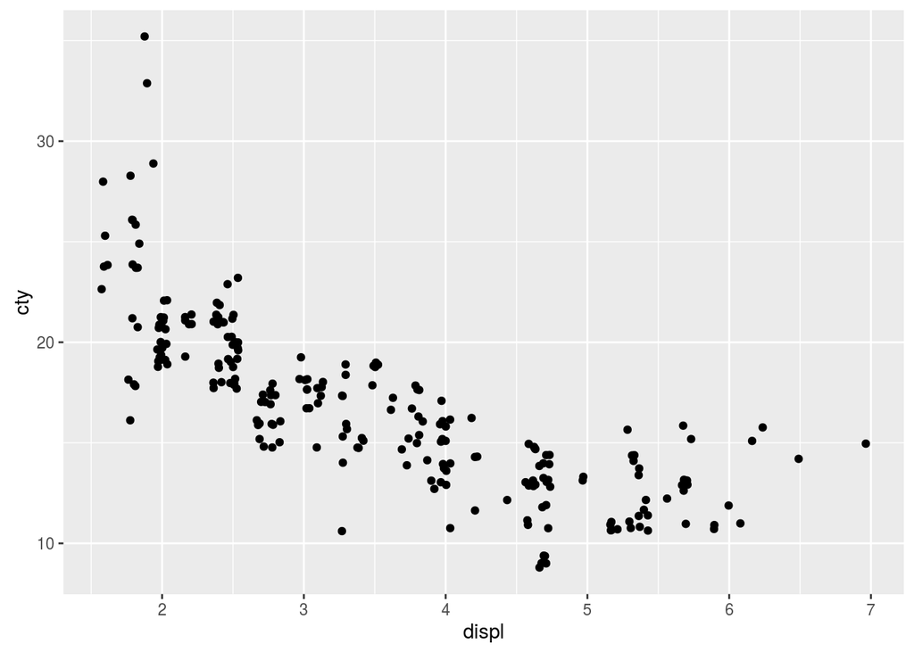

```r
ggplot() +
  geom_jitter(data = mpg, aes(x = displ, y = cty))
```

Что делать, если хочется, чтобы этот график выглядел fancy? Раскрасить его!

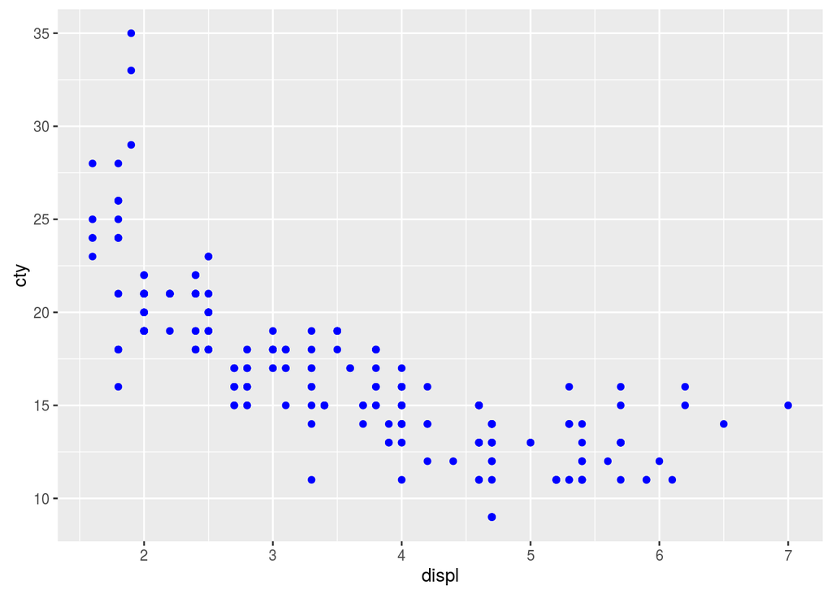

```r
ggplot() +
  geom_point(data = mpg, aes(x = displ, y = cty), color = "blue")
```

Если еще и друзьям (научному руководителю) показать захотелось, тогда надо добавить понятные подписи к осям!

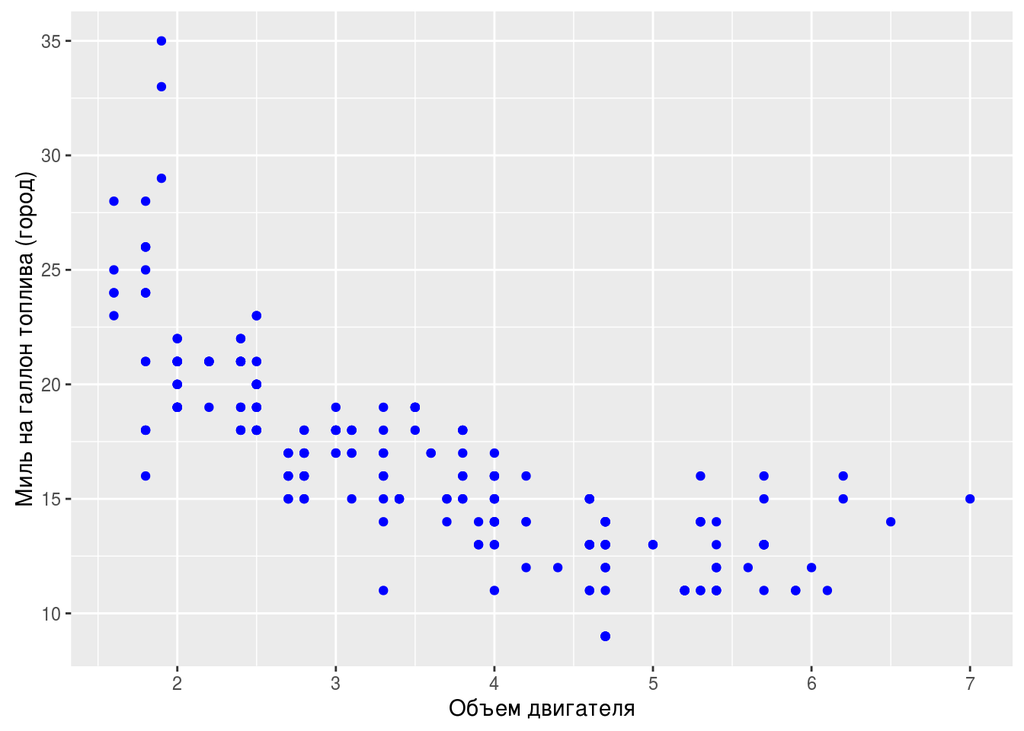

```r
ggplot() +
  geom_point(data = mpg, aes(x = displ, y = cty), color = "blue") +
  xlab("Объем двигателя") +
  ylab("Миль на галлон топлива (город)")
```

А если хочется посмотреть, как это двумерное распределение накладывается на разделение автомобилей на классы?

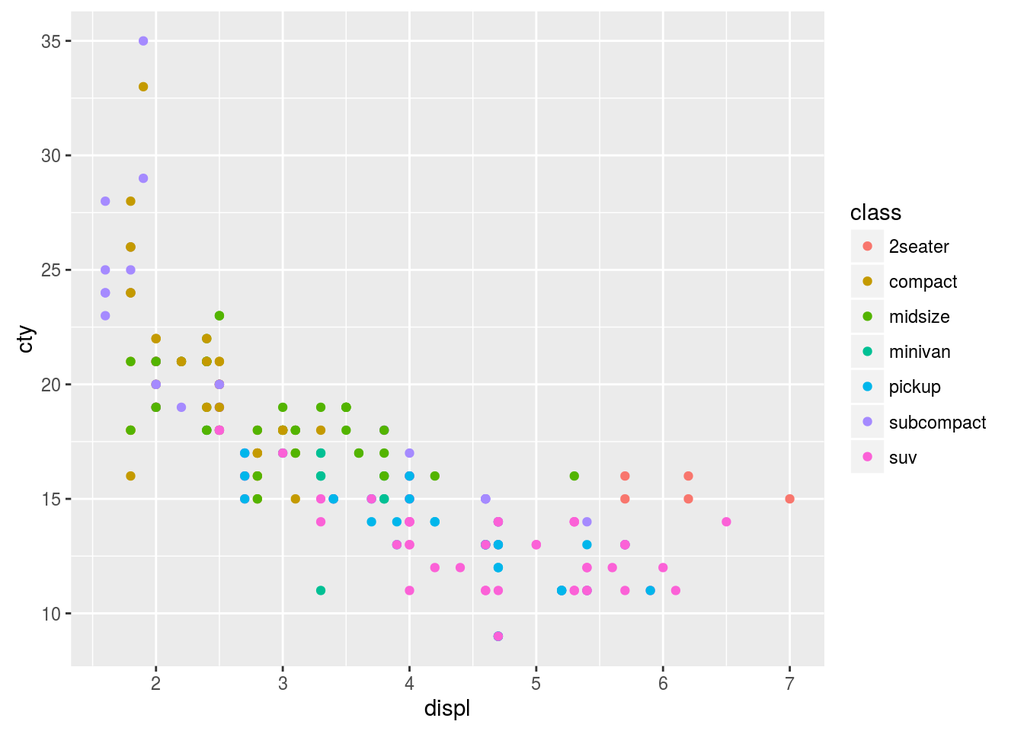

```r
ggplot() +
  geom_point(data = mpg, aes(x = displ, y = cty, color = class))
```

- Данные каких типов можно использовать для каких графиков?

#### 9. Совершенствование решения

Простых графиков не всегда достаточно. Иногда, чтобы ответить на вопрос, нужно исследовать более сложные зависимости (но об этом поговорим следующий раз)

#### 10. Выводы

- Подходящие ли у нас данные?
- Не нужно ли нам собрать что-то дополнительно, чтобы более полно ответить на вопрос?
- Корректен ли наш вопрос?

### Принципы аналитической графики

- Показывайте сравнения
- Показывайте структуру, механизмы, причины и следствия
- Показывайте многомерность данных
- Используйте разные подтверждения вашего результата (текст, цифры и т.д.)
- Описывайте и фиксируйте подтверждения/доказательства (так, чтобы зрителю было понятно)
- Главное – содержание, а не форма

**Вопрос для обсуждения:** Мы рассматривали разведочный анализ данных и, в частности, разведочные графики (Exploratory Graphs). Чем, по вашему мнению, разведочные графики отличаются от финальных, публикуемых в отчетах, презенациях и т.д.?

**Ваша очередь:** Проведите разведочный анализ датасета `msleep` из пакета `ggplot2`

```r
?msleep
```